# NYRB Scouting Report - Data Science Project

Daniel Barir Jensen

2023-03-13

## Introduction to New York Red Bulls

*The New York Red Bulls play a high-energy style of soccer, characterized by aggressive pressing, winning 50/50 balls, and direct passes. The team’s head coach Gerhard Struber emphasizes bringing through players from the academy, and their formation and tactics have included variations of playing with either 3 or 4 at the back. In this report, I will be diving deeper into the NYRB’s offense and highlighting key players and tendencies to look out for. The analysis will be conducted on all match events from the last five games of the 2022 regular season. I will be providing my methodology and code throughout.*

## Outline

- Setting up my environment
- Filtering the data
- Formations used in Starting XI
- Players most frequently used
- Offensive output by game
- Offensive output by player
- Diving deeper into box passes completed
- Diving deeper into shots and goals
- Summary & key takeaways

### Setting up my environment

The first step was setting up my R environment by loading the `StatsBombR`, `tidyverse`, `SBpitch`, and `rmarkdown` packages and reading the `match_data` and `lineups` files provided.

```r
library(StatsBombR)
library(tidyverse)
library(SBpitch)
library(rmarkdown)

match_data = readRDS("match_events_for_test.RDS")
lineups = readRDS('lineups_for_test.RDS')
```

### Filtering the data

Before beginning the analysis, I created an additional variable to clarify the opponent tied to each event:

```r
## Creating opposition team variable
match_data <- get.opposingteam(match_data)
```

I then created a filtered dataframe to focus only on NYRB’s match events:

```r
## Filtering data to select just NYRB
nyrb_data <- match_data %>%
  filter(team.name == "New York Red Bulls")
```

### Formations used in Starting XI

In order to see which formations were used in the starting lineup for the last five games, I first filtered the NYRB data to only show the rows containing information regarding the `Starting XI`. I then aggregated the number of times each formation appeared (`count(tactics.formation)`) in the starting lineup:

```r
# Filtering data to view Starting XI for each of the last 5 matches
starting_xi_data <- nyrb_data %>%
  filter(type.name=="Starting XI")

# Aggregating the number of times a formation was used in the starting lineup
formation_starting_xi <- starting_xi_data %>%
  select(tactics.formation) %>%
  unnest() %>%
  count(tactics.formation, name = "times_used_in_starting_xi") %>%
  arrange(desc(times_used_in_starting_xi))
```

| tactics.formation | times_used_in_starting_xi |
| --- | --- |
| 3412 | 2 |
| 4231 | 2 |
| 343 | 1 |

[output not shown]

### Players most frequently used

I conducted a similar analysis to see which NYRB players appeared in the starting lineup most frequently. I also added the total number of minutes played by each player.

```r
# Number of times a player was in the starting lineup
players_starting_xi <- starting_xi_data %>%
  select(tactics.lineup) %>%
  unnest() %>%
  count(player.name, name = "appearances_in_starting_xi") %>%
  arrange(desc(appearances_in_starting_xi))

# Minutes played by each player
playing_time <- nyrb_data %>%
  select(player.name, player.id) %>%
  distinct() %>%
  na.omit()

minutes_played <- get.minutesplayed(nyrb_data)

minutes_played <- minutes_played %>%
  group_by(player.id) %>%
  summarise(minutes = sum(MinutesPlayed))

playing_time <- left_join(playing_time, minutes_played)

# Joining playing time and appearances in Starting XI
playing_time <- left_join(playing_time, players_starting_xi) %>%
  arrange(desc(minutes))

playing_time <- replace(playing_time, is.na(playing_time), 0)

playing_time <- playing_time %>%
  select(player.name, minutes, appearances_in_starting_xi) %>%
  mutate_if(is.numeric, round, digits = 2)
```

| player.name | minutes | appearances_in_starting_xi |
| --- | --- | --- |
| Sean Nealis | 490.65 | 5 |
| Daniel Edelman | 490.65 | 5 |
| Carlos Miguel Coronel | 490.65 | 5 |
| John Tolkin | 490.65 | 5 |
| Lewis Morgan | 486.68 | 5 |
| Lucas Lima Linhares | 407.22 | 5 |
| Aaron Long | 393.57 | 4 |
| Andrés Felipe Reyes Ambuila | 339.87 | 4 |
| Elias Manoel Alves de Paula | 336.74 | 4 |
| Kyle Duncan | 313.14 | 2 |

[output cut: 10 more lines]

[output not shown]

### Offensive output by game

In order to focus the analysis on NYRB’s offense, I grouped several of NYRB’s most relevant offensive stats by each of the last five regular season matches:

```r
## Grouping NYRB's offensive stats by each of the last five games
nyrb_off_summary <- nyrb_data %>%
  group_by(team.name, OpposingTeam) %>%
  summarise(goals = sum(shot.outcome.name=="Goal", na.rm = TRUE),
            xG = sum(shot.statsbomb_xg, na.rm = TRUE),
            shots = sum(type.name=="Shot"),
            shots_on_target = sum(type.name=="Shot" & shot.outcome.name %in% c("Saved", "Goal"), na.rm = TRUE),
            passes_attempted = sum(type.name=="Pass"),
            passes_completed = sum(type.name=="Pass" & is.na(pass.outcome.name)),
            pass_completion_pct = (passes_completed/passes_attempted*100),
            box_passes_attempted = sum(type.name=="Pass" & pass.end_location.x>=102
                                       & pass.end_location.y<=62 & pass.end_location.y>=18,
                                       nar.rm = TRUE),
            box_passes_completed = sum(type.name=="Pass" & is.na(pass.outcome.name)
                                       & pass.end_location.x>=102 & pass.end_location.y<=62
                                       & pass.end_location.y>=18,
                                       nar.rm = TRUE),
            box_pass_completion_pct = (box_passes_completed/box_passes_attempted*100))
```

| team.name | OpposingTeam | goals | xG | shots | shots_on_target | passes_attempted | passes_completed | pass_completion_pct | box_passes_attempted | box_passes_completed | box_pass_completion_pct |
| --- | --- | --- | --- | --- | --- | --- | --- | --- | --- | --- | --- |
| New York Red Bulls | Charlotte | 2 | 0.5555036 | 12 | 8 | 264 | 151 | 57.19697 | 36 | 10 | 27.77778 |
| New York Red Bulls | Columbus Crew | 1 | 0.4585125 | 10 | 3 | 255 | 129 | 50.58824 | 27 | 7 | 25.92593 |
| New York Red Bulls | New England Revolution | 2 | 1.5348831 | 12 | 5 | 559 | 432 | 77.28086 | 54 | 15 | 27.77778 |
| New York Red Bulls | New York City FC | 0 | 0.7967781 | 9 | 0 | 407 | 271 | 66.58477 | 44 | 15 | 34.09091 |
| New York Red Bulls | Philadelphia Union | 0 | 1.2449933 | 8 | 3 | 455 | 314 | 69.01099 | 27 | 9 | 33.33333 |

[output not shown]

### Offensive output by player

In similar fashion I grouped the offensive stats by each individual player and added the corresponding per 90 stats:

```r
# NYRB offensive stats by individual player
nyrb_off_players <- nyrb_data %>%
  group_by(player.name, player.id) %>%
  summarise(goals = sum(shot.outcome.name=="Goal", na.rm = TRUE),
            xG = sum(shot.statsbomb_xg, na.rm = TRUE),
            shots = sum(type.name=="Shot"),
            shots_on_target = sum(type.name=="Shot" & shot.outcome.name %in% c("Saved", "Goal"), na.rm = TRUE),
            passes_attempted = sum(type.name=="Pass"),
            passes_completed = sum(type.name=="Pass" & is.na(pass.outcome.name)),
            pass_completion_pct = (passes_completed/passes_attempted*100),
            box_passes_attempted = sum(type.name=="Pass" & pass.end_location.x>=102
                                       & pass.end_location.y<=62 & pass.end_location.y>=18,
                                       nar.rm = TRUE),
            box_passes_completed = sum(type.name=="Pass" & is.na(pass.outcome.name)
                                       & pass.end_location.x>=102 & pass.end_location.y<=62
                                       & pass.end_location.y>=18,
                                       nar.rm = TRUE),
            box_pass_completion_pct = (box_passes_completed/box_passes_attempted*100))

# Adding per 90 stats
nyrb_off_players <- left_join(nyrb_off_players, playing_time)

nyrb_off_players <- nyrb_off_players %>%
  filter(minutes >= 90)

nyrb_off_players <- nyrb_off_players %>%
  mutate(nineties = minutes/90,
         goals_p90 = goals/nineties,
         xG_p90 = xG/nineties,
         shots_p90 = shots/nineties,
         shots_on_target_p90 = shots_on_target/nineties,
         passes_attempted_p90 = passes_attempted/nineties,
         passes_completed_p90 = passes_completed/nineties,
         box_passes_attempted_p90 = box_passes_attempted/nineties,
         box_passes_completed_p90 = box_passes_completed/nineties)

nyrb_off_players <- nyrb_off_players[,c(1,13,3,16,4,17,5,18,6,19,7,20,8,21,9,10,22,11,23,12)]

nyrb_off_players <- nyrb_off_players %>%
  mutate_if(is.numeric, round, digits = 2)
```

| player.name | minutes | goals | goals_p90 | xG | xG_p90 | shots | shots_p90 | shots_on_target | shots_on_target_p90 | passes_attempted | passes_attempted_p90 | passes_completed | passes_completed_p90 | pass_completion_pct | box_passes_attempted | box_passes_attempted_p90 | box_passes_completed | box_passes_completed_p90 | box_pass_completion_pct |
| --- | --- | --- | --- | --- | --- | --- | --- | --- | --- | --- | --- | --- | --- | --- | --- | --- | --- | --- | --- |
| Aaron Long | 393.57 | 0 | 0.00 | 0.09 | 0.02 | 2 | 0.46 | 1 | 0.23 | 182 | 41.62 | 133 | 30.41 | 73.08 | 8 | 1.83 | 1 | 0.23 | 12.50 |
| Andrés Felipe Reyes Ambuila | 339.87 | 0 | 0.00 | 0.25 | 0.07 | 3 | 0.79 | 2 | 0.53 | 145 | 38.40 | 110 | 29.13 | 75.86 | 5 | 1.32 | 1 | 0.26 | 20.00 |
| Caden Clark | 113.01 | 0 | 0.00 | 0.14 | 0.11 | 2 | 1.59 | 1 | 0.80 | 21 | 16.72 | 13 | 10.35 | 61.90 | 2 | 1.59 | 2 | 1.59 | 100.00 |
| Carlos Miguel Coronel | 490.65 | 0 | 0.00 | 0.00 | 0.00 | 0 | 0.00 | 0 | 0.00 | 152 | 27.88 | 85 | 15.59 | 55.92 | 4 | 0.73 | 1 | 0.18 | 25.00 |
| Cristian Sleiker Cásseres Yepes | 197.12 | 1 | 0.46 | 0.32 | 0.14 | 5 | 2.28 | 2 | 0.91 | 111 | 50.68 | 79 | 36.07 | 71.17 | 13 | 5.94 | 6 | 2.74 | 46.15 |
| Daniel Edelman | 490.65 | 0 | 0.00 | 0.08 | 0.01 | 3 | 0.55 | 0 | 0.00 | 198 | 36.32 | 150 | 27.51 | 75.76 | 14 | 2.57 | 8 | 1.47 | 57.14 |
| Dru Yearwood | 96.62 | 0 | 0.00 | 0.05 | 0.04 | 1 | 0.93 | 1 | 0.93 | 35 | 32.60 | 23 | 21.42 | 65.71 | 3 | 2.79 | 2 | 1.86 | 66.67 |
| Dylan Nealis | 257.35 | 0 | 0.00 | 0.02 | 0.01 | 1 | 0.35 | 0 | 0.00 | 101 | 35.32 | 49 | 17.14 | 48.51 | 13 | 4.55 | 4 | 1.40 | 30.77 |
| Elias Manoel Alves de Paula | 336.74 | 2 | 0.53 | 1.13 | 0.30 | 9 | 2.41 | 4 | 1.07 | 47 | 12.56 | 26 | 6.95 | 55.32 | 5 | 1.34 | 2 | 0.53 | 40.00 |
| Frankie Amaya | 190.24 | 1 | 0.47 | 0.06 | 0.03 | 2 | 0.95 | 1 | 0.47 | 44 | 20.82 | 29 | 13.72 | 65.91 | 5 | 2.37 | 1 | 0.47 | 20.00 |

[output cut: 6 more lines]

[output not shown]

A total of 20 players have been featured in the last five games of the regular season. 6 players have started in every single game, and 4 players (Sean Nealis, Edelman, Coronel, and Tolkin) have played every single minute. Given this data, we can gain a clearer picture of who we may expect to feature in the upcoming game.

### Diving deeper into box passes completed

In order to gain a better understanding of the NYRB’s offensive and identify key threats, I decided to dive deeper into the team’s chance creation through completed passes into the box (referred to as box passes).

I first created a visualization to plot all of NYRB’s completed box passes (I used the `SBPitch` package to create the pitch visualization and used StatsBomb specifications to define the coordinates of the opposition’s box):

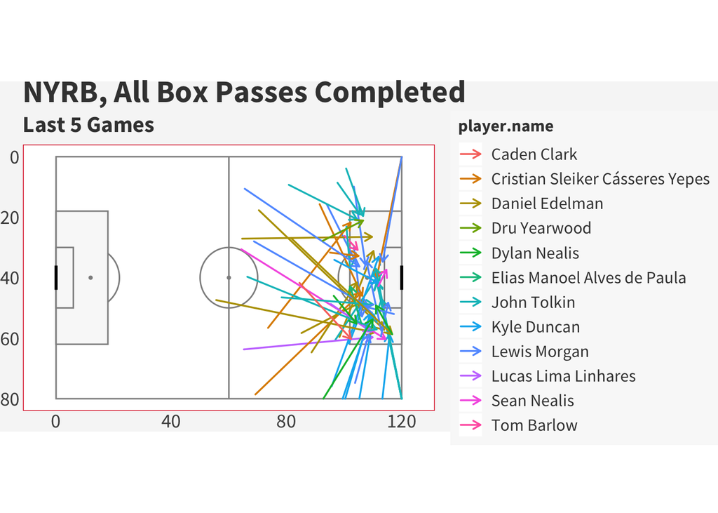

```r
# Plotting box basses completed
box_passes <- nyrb_data %>%
  filter(type.name=="Pass" & is.na(pass.outcome.name)) %>%
  filter(pass.end_location.x>=102 & pass.end_location.y<=62 & pass.end_location.y>=18)

plotted_box_passes <- create_Pitch() +
  geom_segment(data = box_passes, aes(x = location.x, y = location.y,
                                                     xend = pass.end_location.x, yend = pass.end_location.y, color = player.name),
               lineend = "round", linewidth = 0.6, arrow = arrow(length = unit(0.08, "inches"))) +
  labs(title = "NYRB, All Box Passes Completed", subtitle = "Last 5 Games") +
  scale_y_reverse() +
  coord_fixed(ratio = 105/100) +
  theme_SB()
```

In order to make this visualization more digestible, I decided to first identify NYRB’s main passing threats (measured by number of completed box passes). I therefore created a graph to plot the total number of box passes by each NYRB player in descending order:

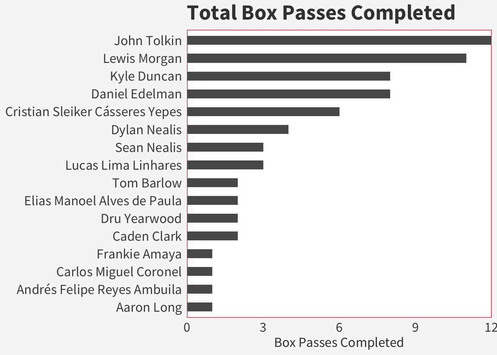

```r
# Graphing total box passes completed by player
player_box_passes <- ggplot(data = nyrb_off_players, aes(x = reorder(player.name, box_passes_completed), y = box_passes_completed)) +
  geom_bar(stat = "identity", width = 0.5) +
  labs(title = "Total Box Passes Completed", y = "Box Passes Completed") +
  theme(axis.title.y = element_blank()) +
  scale_y_continuous(expand = c(0,0)) +
  coord_flip() +
  theme_SB()
```

As you can see in the graph, Tolkin, Morgan, Duncan, Edelman, and Cásseres Jr had the most completed box passes in the last five games. I created a new plotted visualization for these players only, in order to identify the main threats and gain a clearer picture of what these particular passing patterns looked like:

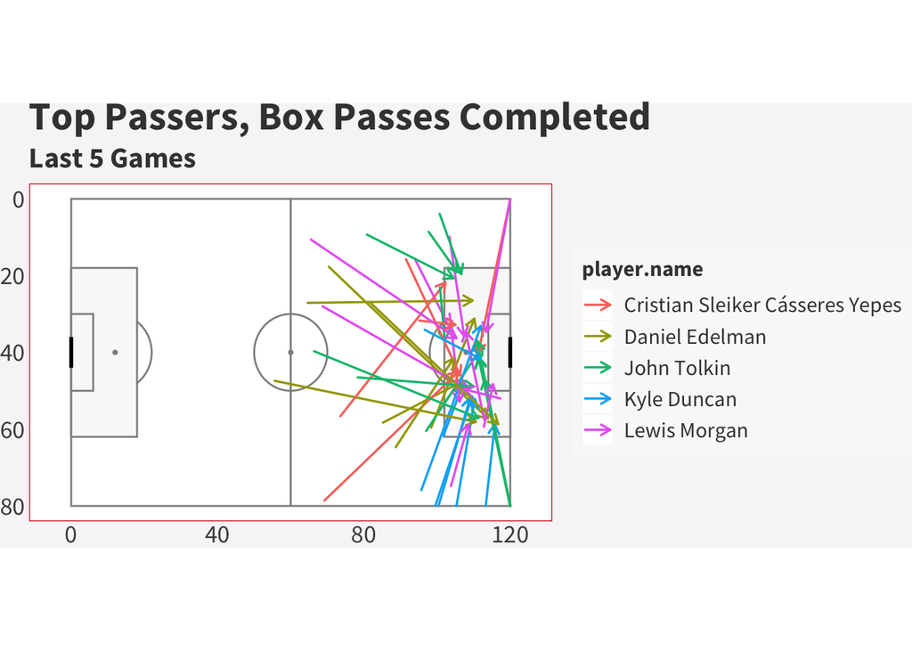

```r
# Plotting box passes completed for top 5 passers
top_box_passers <- box_passes %>%
  filter(player.name %in% c("John Tolkin", "Lewis Morgan", "Kyle Duncan", "Daniel Edelman", "Cristian Sleiker Cásseres Yepes"))

plotted_top_box_passers <- create_Pitch() +
  geom_segment(data = top_box_passers, aes(x = location.x, y = location.y,
                                           xend = pass.end_location.x, yend = pass.end_location.y, color = player.name),
               lineend = "round", linewidth = 0.6, arrow = arrow(length = unit(0.08, "inches"))) +
  labs(title = "Top Passers, Box Passes Completed", subtitle = "Last 5 Games") +
  scale_y_reverse() +
  coord_fixed(ratio = 105/100) +
  theme_SB()
```

By plotting these particular patterns, I noticed that several of the passes in the visualization seemed to come from corner kicks and other set pieces. In order to assess which players may be key threats from **regular play**, I created a filter for `play_pattern.name` = “Regular Play”:

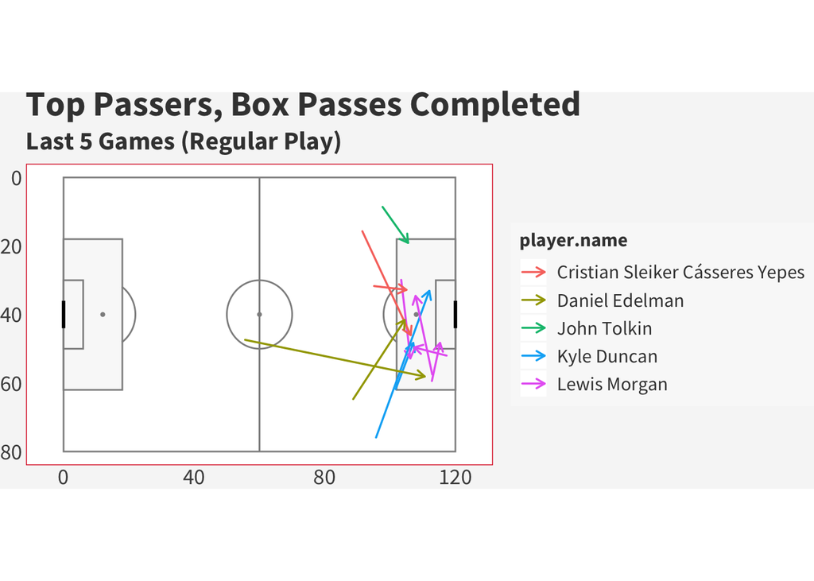

```r
# Plotting box passes completed for top 5 passers in regular play
top_box_passers_regularplay <- top_box_passers %>%
  filter(play_pattern.name=="Regular Play")

plotted_top_box_passers_regularplay <- create_Pitch() +
  geom_segment(data = top_box_passers_regularplay, aes(x = location.x, y = location.y,
                                           xend = pass.end_location.x, yend = pass.end_location.y, color = player.name),
               lineend = "round", linewidth = 0.6, arrow = arrow(length = unit(0.08, "inches"))) +
  labs(title = "Top Passers, Box Passes Completed", subtitle = "Last 5 Games (Regular Play)") +
  scale_y_reverse() +
  coord_fixed(ratio = 105/100) +
  theme_SB()
```

In this final visualization of completed box passes in regular play, it becomes quite clear that John Tolkin and Kyle Duncan primarily provide a passing threat from set pieces. The only player, who stands out is Lewis Morgan with his four completed passes inside the box. Going back to the table I created previously (**Offensive output by player**), we can see that Lewis Morgan also has contributed with a goal and 9 shots in the past five games. Thus we can expect a lot of the chance creation to flow through Lewis Morgan and we should try to limit his touches inside the box.

### Diving deeper into shots and goals

In order to identify trends in NYRB’s finishing patterns, I first plotted every single shot from the last five games and categorized them by the outcome of the shot:

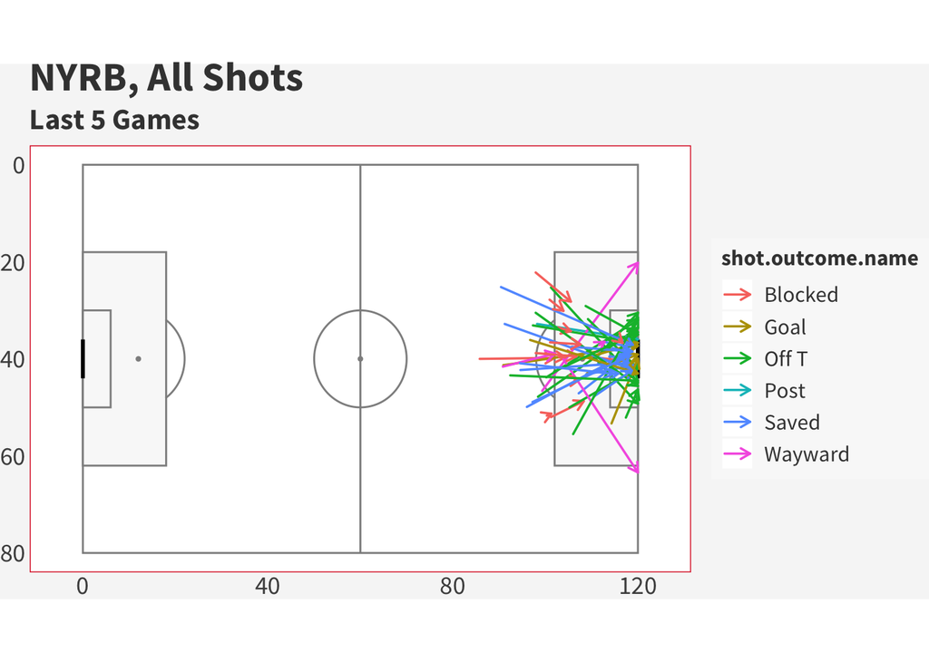

```r
# Plotting all shots
nyrb_shots <- nyrb_data %>%
  filter(type.name=="Shot")

plotted_shots <- create_Pitch() +
  geom_segment(data = nyrb_shots, aes(x = location.x, y = location.y,
                                      xend = shot.end_location.x, yend = shot.end_location.y, color = shot.outcome.name),
               lineend = "round", linewidth = 0.6, arrow = arrow(length = unit(0.08, "inches"))) +
  labs(title = "NYRB, All Shots", subtitle = "Last 5 Games") +
  scale_y_reverse() +
  coord_fixed(ratio = 105/100) +
  theme_SB()
```

It is difficult to gather much from this visualization other than that there is a general tendency for NYRB to shoot from more central positions. In order to gain more insights into NYRB’s chance creation, I created a new visualization that only plots their shots on target (shots classified as `shot.outcome.name` = **“Post”** not included):

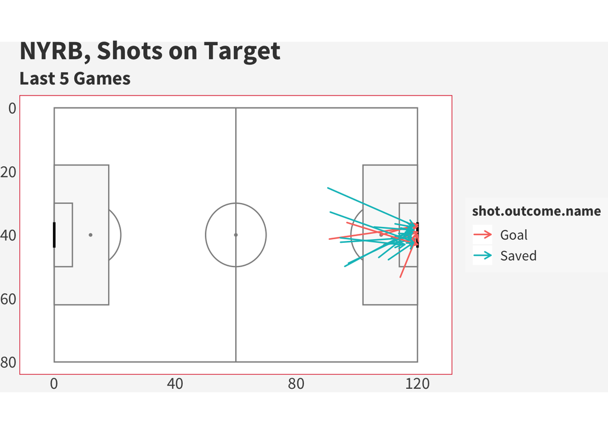

```r
# Plotting all shots on target

nyrb_shots_on_target <- nyrb_data %>%
  filter(type.name=="Shot" & shot.outcome.name %in% c("Goal", "Saved"))

plotted_shots_on_target <- create_Pitch() +
  geom_segment(data = nyrb_shots_on_target, aes(x = location.x, y = location.y,
                                                xend = shot.end_location.x, yend = shot.end_location.y, color = shot.outcome.name),
               lineend = "round", linewidth = 0.6, arrow = arrow(length = unit(0.08, "inches"))) +
  labs(title = "NYRB, Shots on Target", subtitle = "Last 5 Games") +
  scale_y_reverse() +
  coord_fixed(ratio = 105/100) +
  theme_SB()
```

The plotted shots on target show us that NYRB aren’t shy of taking shots from outside the box and two of their last five goals came from outside the box.

In order to identify which NYRB players may be considered their primary goalscoring threats, I graphed the shots per 90 for each player in descending order (I chose the per 90 stat here to not disregard players coming off the bench, who may provide an offensive impact):

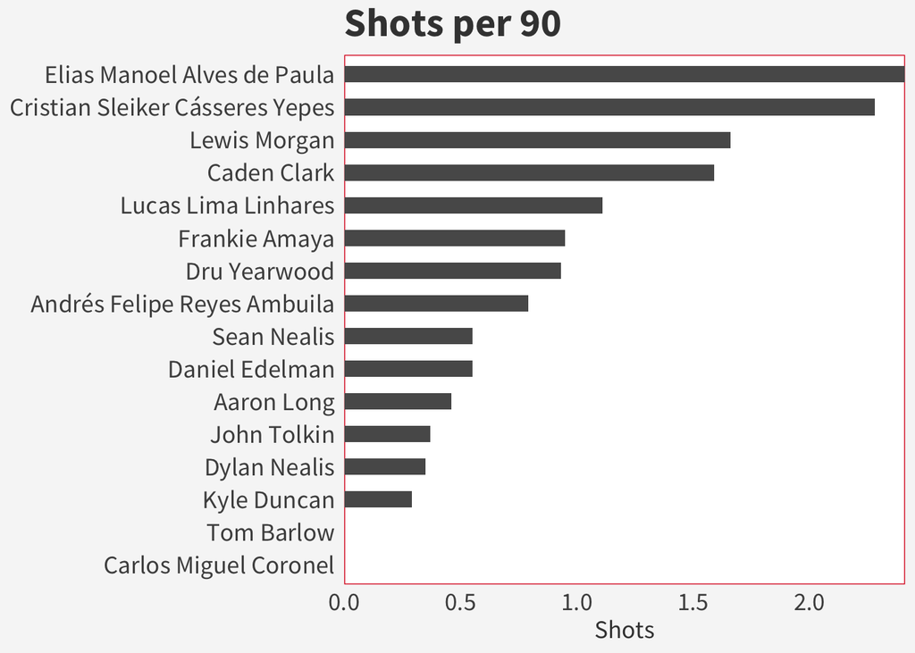

```r
# Graphing shots per 90 by player
player_shots_p90 <- ggplot(data = nyrb_off_players, aes(x = reorder(player.name, shots_p90), y = shots_p90)) +
  geom_bar(stat = "identity", width = 0.5) +
  labs(title = "Shots per 90", y = "Shots") +
  theme(axis.title.y = element_blank()) +
  scale_y_continuous(expand = c(0,0)) +
  coord_flip() +
  theme_SB()
```

The graph reveals that Elias Manoel, Cásseres Jr., Lewis Morgan are the most frequent shooters and that Caden Clark may provide an offensive spark off the bench. It may be effective to mark these players more tightly.

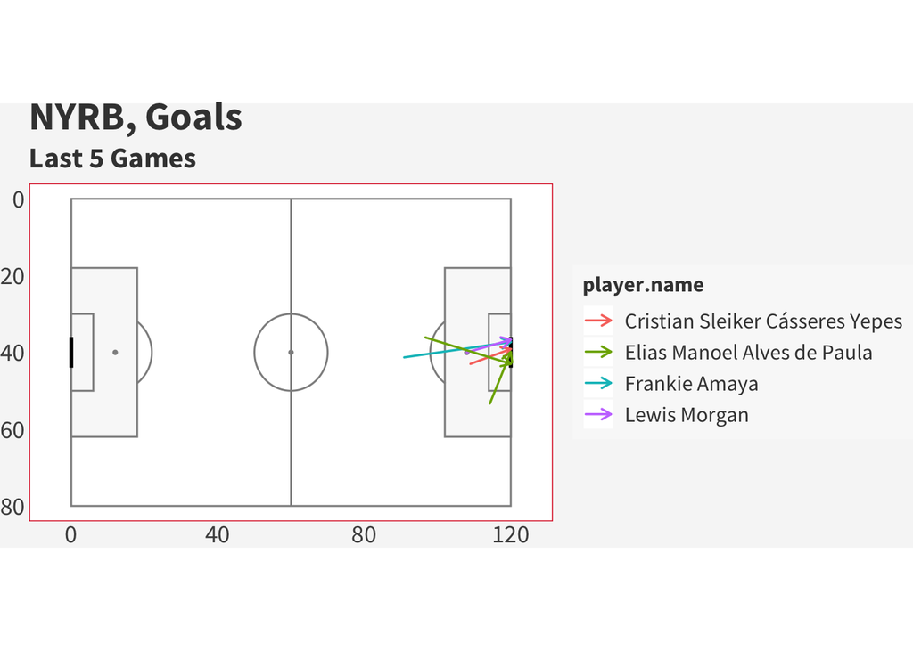

```r
# Plotting all goals

nyrb_goals <- nyrb_data %>%
  filter(shot.outcome.name=="Goal")

plotted_goals <- create_Pitch() +
  geom_segment(data = nyrb_goals, aes(x = location.x, y = location.y,
                                      xend = shot.end_location.x, yend = shot.end_location.y, color = player.name),
               lineend = "round", linewidth = 0.6, arrow = arrow(length = unit(0.08, "inches"))) +
  labs(title = "NYRB, Goals", subtitle = "Last 5 Games") +
  scale_y_reverse() +
  coord_fixed(ratio = 105/100) +
  theme_SB()
```

Finally, I plotted each of NYRB’s last five goals categorized by each goalscorer in order to gain a visual presentation of what each of their goals looked like.

### Summary & Key Takeaways

In summary, I have analyzed the recent performance of New York Red Bulls in their past five regular season games and have identified the most frequently used formations and players. I have also provided tables as an overview of the team’s offensive statistics, as well as individual statistics for featured players. Additionally, I have conducted a deeper analysis of the team’s passing threats by looking at passes into the box, as well as their chance and goal creation by examining frequent shooters and shots plotted on the field.

Key takeaways include:

- NYRB have been using both a 3-back and 4-back system in their games.
- In the last five games, several players had the most completed box passes, including Tolkin, Morgan, Duncan, Edelman, and Cásseres Jr.
- When looking at passing patterns, it was noticed that many of the passes came from corner kicks and other set pieces.
- By filtering for regular play, it was found that John Tolkin and Kyle Duncan primarily provide a passing threat from set pieces, with Lewis Morgan standing out with four completed passes inside the box, as well as contributing with a goal and 9 shots in the past five games.
- The team tends to shoot from more central positions, and the frequency of goals and shots taken revealed that Elias Manoel, Cásseres Jr., and Lewis Morgan should be marked tightly.

Overall, this report provides valuable insights into the team’s offensive strengths and key players and patterns to look out for based on match event data from the last five games.